# Module 2: Installing Packages and Reading Data

Jacob Jameson  
Summer 2021

### Functions

A function is a block of organized, reusable code that is used to perform a single, related action. Functions in R are (most often) verbs, followed by what they will be applied to in parentheses:

```r
sqrt(100)
```

```
[1] 10
```

```r
median(c(3, 4, 5, 6, 7 ))
```

```
[1] 5
```

### Packages

- Packages are collections of functions and data sets developed by the community.
- Two steps to use a package
  - installed with the install.packages function (only once)
  - imported with the library function (once per session)

```r
install.packages("package_name")
library(package_name)
```

- Now Try it yourself

```r
install.packages("tidyverse")
```

```r
library(tidyverse)
```

```r
starwars
```

### What is the Tidyverse?

[figure not shown]

- The tidyverse is an opinionated collection of R packages designed for data science with similar underlying philosophy and a common syntax.

### Loading data from files

Let's load the file called wealth_data.csv into our R environment. To load the file we need to tell our computer where the file is. We do that by choosing a working directory, that is, a local directory on our computer containing the files we need.

To check the current directory

```r
getwd()
```

For this example, we change the path to our new directory at where the lecture slides located. For example:

```r
setwd("/Users/jacob/Downloads/Module 2")
```

Alternatively you can change the working directory using the RStudio GUI using the menu option `Session -> Set Working Directory -> Choose Directory...`

### Loading Data from Files

To load a file from your local directory, there are three steps:

1. Locate the directory of your file in the files tab
2. Set the directory as the working directory by More -> Set As Working Directory
3. Load the data into R using read.csv function

```r
wealth_data=read.csv("wealth_data.csv")
```

The expression read.csv(…) is a function call that asks R to run the function read.csv.

### Data Frame vs Vector vs List

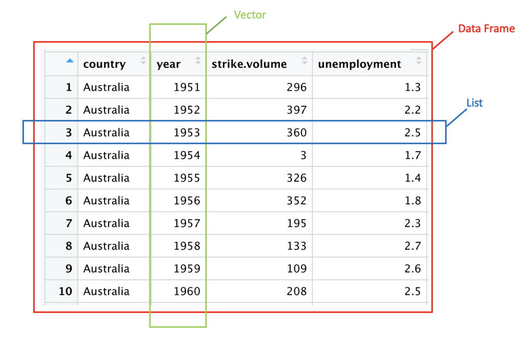

### Data Frame

A data frame is a very important data type in R. It's pretty much the default data structure for most tabular data and what we use for statistics.

Data frames can have additional attributes such as `rownames()`, which can be useful for annotating data, like `subject_id` or `sample_id`. But most of the time they are not used.

### Creating a Data Frame

Usually created when importing the data into R.

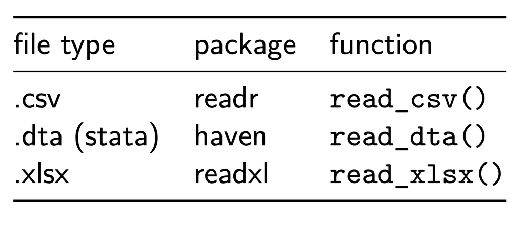

The `tidyverse` package includes all three of these other packages so you only need to remember the function!

### Obtaining Basic Information of Data Frame

- Overview of the data
- Attributes of the data

### Overview of the Data

> - `view()` or `View()` - look at the table
> - `glimpse()`- structure of data frame - name, type and preview of data in each column
> - `summary()` - displays min, 1st quartile, median, mean, 3rd quartile and max - values for numeric attributes.
> - `head()` - shows first 6 rows

```r
view(wealth_data)
glimpse(wealth_data)
summary(wealth_data)
head(wealth_data)
```

### Attributes of the Data

> - `names()` or `colnames()` - both show the names attribute for a data frame
> - `dim()` - returns the dimensions of data frame (i.e. number of rows and number of columns)
> - `nrow()` - number of rows
> - `ncol()` - number of columns

```r
names(wealth_data)
dim(wealth_data)
nrow(wealth_data)
ncol(wealth_data)
```

### Accessing Data

R is a powerful language for data manipulation. There are three main ways for accessing data inside R objects.

- By index (slicing)
- By name (columns only)
- By logical vector (criteria)

### Dataset: Starwars

```r
starwars
view(starwars)
glimpse(starwars)
```

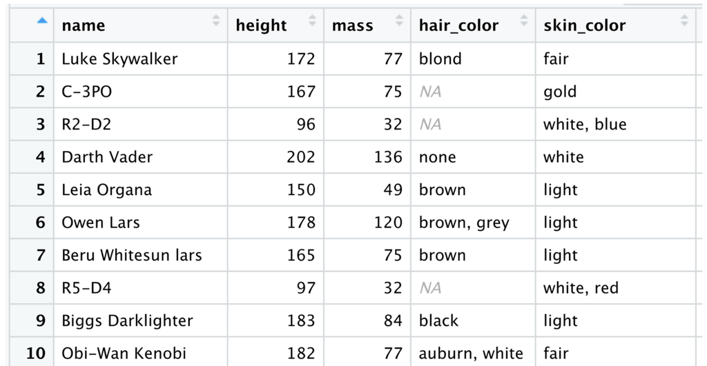

### Accessing by Index

Data can be accessed by index. The generic format is `data_frame[row_numbers,column_numbers]`.

> What will be returned by starwars[1, 1]?

[figure not shown]

If we leave out a dimension R will interpret this as a request for all values in that dimension.

> What will be returned by starwars[, 2]? What will be returned by starwars[1, ]?

The colon `:` can be used to create a sequence of integers.

```r
4:6
```

Creates a vector of numbers from 4 to 6. This can be very useful for accessing data.

> Use the colon operator to index just the hair color, skin color, and eye color (columns 4 to 6).

Finally we can use the c() (combine) function to address non-sequential rows and columns.

```r
starwars[c(1, 5, 7, 9), 1:5]
```

Returns the first 5 columns for characters in rows 1, 5, 7 & 9

> Now try to return the name (column 1) and mass (column 3) values for the first 5 character.

### Accessing by Name

Columns in an R data frame are named.

```r
names(starwars)
```

We usually use the `$` operator to address a column by name

```r
starwars$species
```

### Accessing by Name

> Best Practice

> Best practice is to address columns by name, often you will create or delete columns and the column position will change.

### Accessing by Logical Vector (Criteria)

> Find all characters with species being Human (with missing values)?

```r
criteria = starwars$species == "Human"
starwars[criteria,]$name
```

Often this operation is written as one line of code:

```r
starwars[starwars$species == "Human",]$name
```

> Exercise: Find all characters with height greater than 170 (with missing values)?

### Functions for Missing Values

> - `na.omit(dataframe)` - removes the missing values in data frame
> - `is.na(dataframe$colname)` - indicates which elements are missing

```r
na.omit(starwars)
starwars[!is.na(starwars$species),]
```

### Recap: Installing Packages and Reading Data

After going through this video, you should understand how to:

- install packages using `install.packages()` and load them using `library()`
  - particularly, the package `tidyverse` using `library(tidyverse)`
- Index into a dataframe by:
  - index (slicing)
  - name (columns only)
  - logical vector (criteria)